# Image features exercise

*Complete and hand in this completed worksheet (including its outputs and any supporting code outside of the worksheet) with your assignment submission. For more details see the [assignments page](https://compsci682-fa19.github.io/assignments2019/assignment1) on the course website.*

We have seen that we can achieve reasonable performance on an image classification task by training a linear classifier on the pixels of the input image. In this exercise we will show that we can improve our classification performance by training linear classifiers not on raw pixels but on features that are computed from the raw pixels.

All of your work for this exercise will be done in this notebook.

```python
from __future__ import print_function
import random
import numpy as np
from cs682.data_utils import load_CIFAR10
import matplotlib.pyplot as plt


%matplotlib inline
plt.rcParams['figure.figsize'] = (10.0, 8.0) # set default size of plots
plt.rcParams['image.interpolation'] = 'nearest'
plt.rcParams['image.cmap'] = 'gray'

# for auto-reloading extenrnal modules
# see http://stackoverflow.com/questions/1907993/autoreload-of-modules-in-ipython
%load_ext autoreload
%autoreload 2
```

## Load data

Similar to previous exercises, we will load CIFAR-10 data from disk.

```python
from cs682.features import color_histogram_hsv, hog_feature

def get_CIFAR10_data(num_training=49000, num_validation=1000, num_test=1000):
    # Load the raw CIFAR-10 data
    cifar10_dir = 'cs682/datasets/cifar-10-batches-py'

    X_train, y_train, X_test, y_test = load_CIFAR10(cifar10_dir)

    # Subsample the data
    mask = list(range(num_training, num_training + num_validation))
    X_val = X_train[mask]
    y_val = y_train[mask]
    mask = list(range(num_training))
    X_train = X_train[mask]
    y_train = y_train[mask]
    mask = list(range(num_test))
    X_test = X_test[mask]
    y_test = y_test[mask]

    return X_train, y_train, X_val, y_val, X_test, y_test

# Cleaning up variables to prevent loading data multiple times (which may cause memory issue)
try:
   del X_train, y_train
   del X_test, y_test
   print('Clear previously loaded data.')
except:
   pass

X_train, y_train, X_val, y_val, X_test, y_test = get_CIFAR10_data()
```

## Extract Features

For each image we will compute a Histogram of Oriented Gradients (HOG) as well as a color histogram using the hue channel in HSV color space. We form our final feature vector for each image by concatenating the HOG and color histogram feature vectors.

Roughly speaking, HOG should capture the texture of the image while ignoring color information, and the color histogram represents the color of the input image while ignoring texture. As a result, we expect that using both together ought to work better than using either alone. Verifying this assumption would be a good thing to try for your interests.

The `hog_feature` and `color_histogram_hsv` functions both operate on a single image and return a feature vector for that image. The extract_features function takes a set of images and a list of feature functions and evaluates each feature function on each image, storing the results in a matrix where each column is the concatenation of all feature vectors for a single image.

```python
from cs682.features import *

num_color_bins = 25 # Number of bins in the color histogram
feature_fns = [hog_feature, lambda img: color_histogram_hsv(img, nbin=num_color_bins)]
X_train_feats = extract_features(X_train, feature_fns, verbose=True)
X_val_feats = extract_features(X_val, feature_fns)
X_test_feats = extract_features(X_test, feature_fns)

# Preprocessing: Subtract the mean feature
mean_feat = np.mean(X_train_feats, axis=0, keepdims=True)
X_train_feats -= mean_feat
X_val_feats -= mean_feat
X_test_feats -= mean_feat

# Preprocessing: Divide by standard deviation. This ensures that each feature
# has roughly the same scale.
std_feat = np.std(X_train_feats, axis=0, keepdims=True)
X_train_feats /= std_feat
X_val_feats /= std_feat
X_test_feats /= std_feat

# Preprocessing: Add a bias dimension
X_train_feats = np.hstack([X_train_feats, np.ones((X_train_feats.shape[0], 1))])
X_val_feats = np.hstack([X_val_feats, np.ones((X_val_feats.shape[0], 1))])
X_test_feats = np.hstack([X_test_feats, np.ones((X_test_feats.shape[0], 1))])
```

```
Done extracting features for 1000 / 49000 images
Done extracting features for 2000 / 49000 images
Done extracting features for 3000 / 49000 images
Done extracting features for 4000 / 49000 images
Done extracting features for 5000 / 49000 images
Done extracting features for 6000 / 49000 images
Done extracting features for 7000 / 49000 images
Done extracting features for 8000 / 49000 images
Done extracting features for 9000 / 49000 images
Done extracting features for 10000 / 49000 images
Done extracting features for 11000 / 49000 images
Done extracting features for 12000 / 49000 images
Done extracting features for 13000 / 49000 images
Done extracting features for 14000 / 49000 images
Done extracting features for 15000 / 49000 images
Done extracting features for 16000 / 49000 images
Done extracting features for 17000 / 49000 images
Done extracting features for 18000 / 49000 images
Done extracting features for 19000 / 49000 images
Done extracting features for 20000 / 49000 images
Done extracting features for 21000 / 49000 images
Done extracting features for 22000 / 49000 images
Done extracting features for 23000 / 49000 images
Done extracting features for 24000 / 49000 images
Done extracting features for 25000 / 49000 images
Done extracting features for 26000 / 49000 images
Done extracting features for 27000 / 49000 images
Done extracting features for 28000 / 49000 images
Done extracting features for 29000 / 49000 images
Done extracting features for 30000 / 49000 images
Done extracting features for 31000 / 49000 images
Done extracting features for 32000 / 49000 images
Done extracting features for 33000 / 49000 images
Done extracting features for 34000 / 49000 images
Done extracting features for 35000 / 49000 images
Done extracting features for 36000 / 49000 images
Done extracting features for 37000 / 49000 images
Done extracting features for 38000 / 49000 images
Done extracting features for 39000 / 49000 images
Done extracting features for 40000 / 49000 images
Done extracting features for 41000 / 49000 images
Done extracting features for 42000 / 49000 images
Done extracting features for 43000 / 49000 images
Done extracting features for 44000 / 49000 images
Done extracting features for 45000 / 49000 images
Done extracting features for 46000 / 49000 images
Done extracting features for 47000 / 49000 images
Done extracting features for 48000 / 49000 images
```

## Train SVM on features

Using the multiclass SVM code developed earlier in the assignment, train SVMs on top of the features extracted above; this should achieve better results than training SVMs directly on top of raw pixels.

```python
# Use the validation set to tune the learning rate and regularization strength

from cs682.classifiers.linear_classifier import LinearSVM

# learning_rates = [1e-9, 1e-8, 1e-7, 1e-6, 1e-5]
# regularization_strengths = [1e3, 1e4, 5e4, 5e5, 5e6]
learning_rates = [5e-7, 1e-6, 2.5e-6, 5e-6, 7.5e-6, 1e-5, 5e-5, 1e-4, 5e-4]
regularization_strengths = [1e2, 5e2, 1e3, 5e3, 1e4, 5e4]

results = {}
best_val = -1
best_svm = None

################################################################################
# TODO:                                                                        #
# Use the validation set to set the learning rate and regularization strength. #
# This should be identical to the validation that you did for the SVM; save    #
# the best trained classifer in best_svm. You might also want to play          #
# with different numbers of bins in the color histogram. If you are careful    #
# you should be able to get accuracy of near 0.44 on the validation set.       #
################################################################################
np.random.seed(123)
num_trials = 200
for t in range(num_trials):
#   print ('learning rate: %f, regularization strength: %f' %(lr, rs))
    lr = 10 ** np.random.uniform (-7.5, -4)
    rs = 10 ** np.random.uniform (1,5)
    svm = LinearSVM()
    loss_hist = svm.train(X_train_feats, y_train, learning_rate=lr, reg=rs,
                  num_iters=1000, batch_size=400, verbose=False)
    y_train_pred = svm.predict(X_train_feats)
    train_acc = np.mean(y_train == y_train_pred)
#   print('training accuracy: %f' % (train_acc))
    y_val_pred = svm.predict(X_val_feats)
    val_acc = np.mean(y_val == y_val_pred)
#   print('validation accuracy: %f' % (val_acc))
    results [(lr, rs)] = (train_acc, val_acc)
    if (val_acc > best_val):
        best_val = val_acc
        best_svm = svm

################################################################################
#                              END OF YOUR CODE                                #
################################################################################

# Print out results.
for lr, reg in sorted(results):
    train_accuracy, val_accuracy = results[(lr, reg)]
    print('lr %e reg %e train accuracy: %f val accuracy: %f' % (
                lr, reg, train_accuracy, val_accuracy))

print('best validation accuracy achieved during cross-validation: %f' % best_val)
```

```
lr 3.215477e-08 reg 5.523815e+02 train accuracy: 0.097286 val accuracy: 0.099000
lr 3.399504e-08 reg 1.592791e+04 train accuracy: 0.128286 val accuracy: 0.130000
lr 3.552800e-08 reg 2.347738e+01 train accuracy: 0.114633 val accuracy: 0.097000
lr 3.708583e-08 reg 7.259182e+01 train accuracy: 0.104286 val accuracy: 0.128000
lr 3.731825e-08 reg 1.216398e+01 train accuracy: 0.106388 val accuracy: 0.101000
lr 3.783558e-08 reg 1.684695e+03 train accuracy: 0.107429 val accuracy: 0.095000
lr 4.687757e-08 reg 4.343593e+01 train accuracy: 0.104122 val accuracy: 0.100000
lr 4.959981e-08 reg 1.646587e+02 train accuracy: 0.122776 val accuracy: 0.140000
lr 5.361862e-08 reg 2.310790e+03 train accuracy: 0.115020 val accuracy: 0.126000
lr 5.424113e-08 reg 1.926131e+02 train accuracy: 0.107918 val accuracy: 0.099000
lr 5.579342e-08 reg 6.632885e+03 train accuracy: 0.104265 val accuracy: 0.104000
lr 5.931982e-08 reg 1.682655e+03 train accuracy: 0.096510 val accuracy: 0.093000
lr 6.057849e-08 reg 1.225719e+02 train accuracy: 0.110592 val accuracy: 0.107000
lr 6.099074e-08 reg 1.313430e+04 train accuracy: 0.112918 val accuracy: 0.108000
lr 6.138025e-08 reg 6.599516e+01 train accuracy: 0.099776 val accuracy: 0.103000
lr 6.241379e-08 reg 3.684925e+03 train accuracy: 0.097796 val accuracy: 0.085000
lr 6.679378e-08 reg 9.758148e+03 train accuracy: 0.100490 val accuracy: 0.092000
lr 7.336283e-08 reg 1.650692e+01 train accuracy: 0.104469 val accuracy: 0.108000
lr 7.753666e-08 reg 3.373391e+03 train accuracy: 0.127143 val accuracy: 0.125000
lr 8.371576e-08 reg 7.639510e+02 train accuracy: 0.125000 val accuracy: 0.126000
lr 9.673969e-08 reg 4.534152e+01 train accuracy: 0.101184 val accuracy: 0.112000
lr 1.019249e-07 reg 7.395322e+03 train accuracy: 0.111327 val accuracy: 0.104000
lr 1.047759e-07 reg 1.489352e+01 train accuracy: 0.096633 val accuracy: 0.105000
lr 1.062432e-07 reg 2.380446e+03 train accuracy: 0.111204 val accuracy: 0.118000
lr 1.085271e-07 reg 8.482845e+01 train accuracy: 0.113367 val accuracy: 0.121000
lr 1.120190e-07 reg 2.836335e+02 train accuracy: 0.126347 val accuracy: 0.129000
lr 1.121666e-07 reg 2.854463e+04 train accuracy: 0.414490 val accuracy: 0.407000
lr 1.160666e-07 reg 1.330320e+03 train accuracy: 0.118429 val accuracy: 0.115000
lr 1.206724e-07 reg 1.382925e+03 train accuracy: 0.103082 val accuracy: 0.109000
lr 1.210385e-07 reg 1.684383e+04 train accuracy: 0.281041 val accuracy: 0.271000
lr 1.215481e-07 reg 4.409044e+02 train accuracy: 0.127367 val accuracy: 0.125000
lr 1.417455e-07 reg 1.992695e+02 train accuracy: 0.114224 val accuracy: 0.102000
lr 1.561872e-07 reg 5.839544e+02 train accuracy: 0.114571 val accuracy: 0.121000
lr 1.563581e-07 reg 1.216483e+04 train accuracy: 0.282837 val accuracy: 0.296000
lr 1.610030e-07 reg 4.254853e+03 train accuracy: 0.130347 val accuracy: 0.121000
lr 1.668774e-07 reg 2.391839e+04 train accuracy: 0.422510 val accuracy: 0.427000
lr 1.867786e-07 reg 2.206809e+04 train accuracy: 0.422102 val accuracy: 0.418000
lr 1.884455e-07 reg 6.781663e+04 train accuracy: 0.420714 val accuracy: 0.427000
lr 1.997262e-07 reg 6.179427e+04 train accuracy: 0.422694 val accuracy: 0.431000
lr 2.060173e-07 reg 2.313650e+01 train accuracy: 0.151531 val accuracy: 0.144000
```

[output cut: 146 more lines]

```
lr 4.359904e-05 reg 1.767997e+02 train accuracy: 0.421490 val accuracy: 0.430000
lr 4.500832e-05 reg 2.420866e+03 train accuracy: 0.406061 val accuracy: 0.407000
lr 4.720947e-05 reg 6.716030e+02 train accuracy: 0.419633 val accuracy: 0.418000
lr 4.772076e-05 reg 1.114902e+01 train accuracy: 0.424204 val accuracy: 0.434000
lr 5.231552e-05 reg 1.079649e+02 train accuracy: 0.422245 val accuracy: 0.424000
lr 5.246390e-05 reg 2.575231e+01 train accuracy: 0.421735 val accuracy: 0.426000
lr 5.833050e-05 reg 5.683436e+01 train accuracy: 0.422571 val accuracy: 0.420000
lr 7.307664e-05 reg 2.048875e+02 train accuracy: 0.416551 val accuracy: 0.411000
lr 7.399916e-05 reg 1.289937e+02 train accuracy: 0.421592 val accuracy: 0.425000
lr 7.424579e-05 reg 1.605049e+01 train accuracy: 0.424367 val accuracy: 0.426000
lr 7.638568e-05 reg 6.064908e+02 train accuracy: 0.415245 val accuracy: 0.407000
lr 7.923079e-05 reg 3.758559e+02 train accuracy: 0.426224 val accuracy: 0.434000
lr 8.297855e-05 reg 7.731149e+03 train accuracy: 0.317633 val accuracy: 0.320000
lr 8.490819e-05 reg 2.933328e+04 train accuracy: 0.100265 val accuracy: 0.087000
best validation accuracy achieved during cross-validation: 0.440000
```

```python
# Evaluate your trained SVM on the test set
y_test_pred = best_svm.predict(X_test_feats)
test_accuracy = np.mean(y_test == y_test_pred)
print(test_accuracy)
```

```
0.436
```

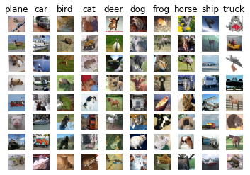

```python
# An important way to gain intuition about how an algorithm works is to
# visualize the mistakes that it makes. In this visualization, we show examples
# of images that are misclassified by our current system. The first column
# shows images that our system labeled as "plane" but whose true label is
# something other than "plane".

examples_per_class = 8
classes = ['plane', 'car', 'bird', 'cat', 'deer', 'dog', 'frog', 'horse', 'ship', 'truck']
for cls, cls_name in enumerate(classes):
    idxs = np.where((y_test != cls) & (y_test_pred == cls))[0]
    idxs = np.random.choice(idxs, examples_per_class, replace=False)
    for i, idx in enumerate(idxs):
        plt.subplot(examples_per_class, len(classes), i * len(classes) + cls + 1)
        plt.imshow(X_test[idx].astype('uint8'))
        plt.axis('off')
        if i == 0:
            plt.title(cls_name)
plt.show()
```

### Inline question 1:

Describe the misclassification results that you see. Do they make sense?

Answer: The misclassification reflects the low capacity of the SVM model. The classifier is unable to distinguish between images that have similar hues, color ranges and texture patterns but belong to different classes.

## Neural Network on image features

Earlier in this assigment we saw that training a two-layer neural network on raw pixels achieved better classification performance than linear classifiers on raw pixels. In this notebook we have seen that linear classifiers on image features outperform linear classifiers on raw pixels.

For completeness, we should also try training a neural network on image features. This approach should outperform all previous approaches: you should easily be able to achieve over 55% classification accuracy on the test set; our best model achieves about 60% classification accuracy.

```python
# Preprocessing: Remove the bias dimension
# Make sure to run this cell only ONCE
print(X_train_feats.shape)
X_train_feats = X_train_feats[:, :-1]
X_val_feats = X_val_feats[:, :-1]
X_test_feats = X_test_feats[:, :-1]

print(X_train_feats.shape)
```

```
(49000, 170)
(49000, 169)
```

```python
from cs682.classifiers.neural_net import TwoLayerNet

input_dim = X_train_feats.shape[1]
hidden_dim = 500
num_classes = 10

net = TwoLayerNet(input_dim, hidden_dim, num_classes)
best_net = None

################################################################################
# TODO: Train a two-layer neural network on image features. You may want to    #
# cross-validate various parameters as in previous sections. Store your best   #
# model in the best_net variable.                                              #
################################################################################
num_classes = 10

hidden_sizes = [100, 200, 400, 800, 1600]
learning_rates = [1, 1e-1]
regularizations = [1e-4, 1e-3, 1e-2]
batch_sizes = [100, 200, 400, 800]
best_val_acc = 0
best_hyperparams = None
for hs in hidden_sizes:
    for bs in batch_sizes:
        num_trials = 5
        for t in range(num_trials):
            # Train the network
            lr = 10 ** np.random.uniform (-1,0)
            rs = 10 ** np.random.uniform (-4,-2)
            # Train the network
            net = TwoLayerNet(input_dim, hs, num_classes)
            stats = net.train(X_train_feats, y_train, X_val_feats, y_val,
                        num_iters=2000, batch_size=bs,
                        learning_rate=lr, learning_rate_decay=0.95,
                        reg=reg, verbose=False)

            # Predict on the train set
            train_acc = (net.predict(X_train_feats) == y_train).mean()

            # Predict on the validation set
            val_acc = (net.predict(X_val_feats) == y_val).mean()
            print (val_acc, train_acc, hs, bs, lr, reg)
            if best_val_acc < val_acc:
                best_val_acc = val_acc
                best_net = net
                best_hyper_params = (val_acc, train_acc, hs, bs, lr, reg)
print('Best validation accuracy: ', best_val_acc)
print('Best hyper params: ', best_hyper_params)
################################################################################
#                              END OF YOUR CODE                                #
################################################################################
```

[output not shown]

[output cut: 67 more lines]

[output not shown]

```python
# Run your best neural net classifier on the test set. You should be able
# to get more than 55% accuracy.

test_acc = (best_net.predict(X_test_feats) == y_test).mean()
print(test_acc)
```

```
0.599
```